# Lab 3: optimising linear algebra

Hasnain Cheena, 190411106, hche737

13 August 2020

Linear algebra is fundamental for data science. Standard CPUs aren’t very good at it: they can spend nearly all the time getting data on and off the CPU and very little time doing productive calculations. Specially designed chips for matrix operations (GPUs) and higher-dimensional tensor operations (TPUs) are the future way around this problem, but optimising data flow is important even there.

The basic idea is to partition a matrix into blocks, chosen to match features of the computer such as cache size. It’s hard to derive the optimal block size from first principles, so optimisation is done by measuring many problems of different sizes and trying to fit a model of some sort to find the best settings.

The data (`sgemm_product.csv`) is the result of an exhaustive experiment (`Readme.txt`) in optimising matrix-matrix multiplication for a particular GPU. There are 14 predictor variables in 261400 possible combinations. For each combination there are timings for four runs of multiplying two $2048\times 2048$ matrices. Typically we would not have such exhaustive data, so we want to know how good the prediction from a subsample will be.

You will model `log(time)`, not `time`, because that’s what the experiment was designed for. The effects of the variables should be closer to multiplicative than additive.

Some useful code for setting up the design matrix and doing the cross-validation is on Canvas for this lab.

## Tasks

### Question 1: Read in the data and choose your own random sample of 500 rows

```r
df= read_csv('sgemm_product.csv.')

set.seed(190411106)

#use slice_sample to get random sample of 500 rows
subsample.df= df %>%
  slice_sample(n=500) %>%
  mutate(log.time1 = log(`Run1 (ms)`),
         log.time2 = log(`Run2 (ms)`))
```

### Question 2: Using the `leaps` package, as in class, run backwards stepwise selection to predict timings from the **logarithm of time** for first run on models with all 14 predictors and all two-way interactions. Look at models with up to 20 variables. Plot the apparent error against the number of predictors.

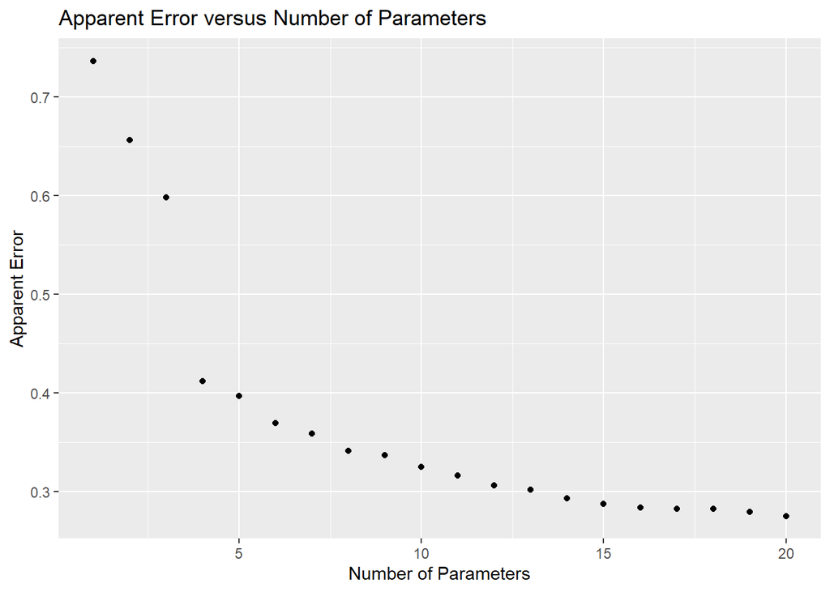

```r
#create model matrix with all 2 way interactions
mf = cbind(subsample.df[, 1:14], log.time1 = subsample.df$log.time1)
model.matrix <-model.matrix(log.time1~.^2, mf)[,-1]
#search for models
bsearch = regsubsets(model.matrix,subsample.df$log.time1,nvmax=20, method="back")
summ = summary(bsearch)
#plot apparent error versus number of parameters
apparent.error = data.frame("p"=1:20, "apparent.error" = summ$rss/(500 - 1:20))
ggplot(apparent.error, aes(x=p, y=apparent.error)) + geom_point() +
  ggtitle("Apparent Error versus Number of Parameters") +
  labs(y="Apparent Error", x = "Number of Parameters")
```

### Question 3: Using cross-validation, select a tuning parameter $\lambda$ so that minimising $n\log\mathrm{RSS}+\lambda p$ gives good mean squared prediction error, and select a predictive model.

Note that in this analysis it is assumed that models of only upto 20 variables are considered and and all two-way interactions are included.

```r
y<-subsample.df$log.time1
X<-model.matrix

yhat<-function(xtrain, ytrain, xtest,lambda){
  n.variables = 20
  search<-regsubsets(xtrain,ytrain, nvmax=n.variables, method="back")
  summ<-summary(search)
  aic<-nrow(xtrain)*log(summ$rss)+lambda*(1:n.variables)
  best<-which.min(aic)#lowest AIC
  betahat<-coef(search, best)#coefficients for the best model
  xinmodel<-cbind(1,xtest)[,summ$which[best,]]#predictors in that model
  yhat<-xinmodel%*%betahat
}

xvalMSPE<-function(lambda){
  folds<-sample(rep(1:10,10))
  fitted<-numeric(nrow(X))

  for(k in 1:10){
    train<-(1:nrow(X))[folds!=k]
    test<-(1:nrow(X))[folds==k]
    fitted[test]<-yhat(X[train,],y[train],X[test,], lambda)
  }
  mean((y-fitted)^2)
}

lambdas<-seq(2,12,2)
MSPE = sapply(lambdas, xvalMSPE)

data.frame("lambda" = lambdas, "MSPE" = MSPE)
```

```
##   lambda      MSPE
## 1      2 0.3367395
## 2      4 0.3190493
## 3      6 0.3443023
## 4      8 0.3479154
## 5     10 0.3446880
## 6     12 0.3460910
```

Can see from the output above that a good predictive model has a $\lambda = 4$. Next fit the model on the full subset of data.

```r
n.variables = 20
best.lambda = 4
#extract features and labels
y<-subsample.df$log.time1
X<-model.matrix
#search for model
search<-regsubsets(X,y, nvmax=n.variables, method="back")
summ<-summary(search)
#find best model for selected lambda
penalised.aic<-nrow(X)*log(summ$rss)+best.lambda*(1:n.variables)
best<-which.min(penalised.aic)#lowest AIC
#coefficients of best model
coefficients = coef(search, best)#coefficients for the best model
coefficients
```

```
##   (Intercept)           MWG         NDIMC         NDIMB          STRM
##  3.3670875678  0.0172432333  0.0885599126 -0.0255626960 -0.4840012426
##       MWG:NWG     MWG:MDIMC     MWG:NDIMC     NWG:MDIMC     NWG:NDIMC
##  0.0001787836 -0.0007188341 -0.0006328737 -0.0004042239 -0.0004431713
##       NWG:VWN      NWG:STRM        NWG:SA     KWG:MDIMC     MDIMC:VWN
##  0.0014890710  0.0040194200  0.0039475525  0.0015080539 -0.0051464318
##   NDIMC:MDIMA     NDIMC:VWM     NDIMC:VWN      NDIMC:SA   MDIMA:NDIMB
## -0.0008644173 -0.0055716742 -0.0089084088 -0.0308430128  0.0009765169
##     NDIMB:VWM
##  0.0040715158
```

Coefficients of model selected are shown above.

### Question 4: Estimate the actual mean squared prediction error of your model using the second replicate of the experiment (`log(Run2)`) in your sample data set.

```r
#features and labels of sample data
y2<-subsample.df$log.time2
X<-model.matrix

betahat<-coef(search, best)#coefficients for the best model
xinmodel<-cbind(1,X)[,summ$which[best,]]#predictors in that model
yhat<-xinmodel%*%betahat

mean((y2-yhat)^2)
```

```
## [1] 0.2644909
```

Actual MSPE of selected model using the second replicate of the experiment and subsample of dataset is approximately 0.26ms.

### Question 5: Estimate the actual mean squared prediction error of your model using the second replicate of the experiment (`log(Run2)`) on all 261400 observations

```r
#log response variable
df = df %>%
  mutate(log.time2 = log(`Run2 (ms)`))
mf = cbind(df[, 1:14], log.time2 = df$log.time2)
#features and labels from entire dataset
X <-model.matrix(log.time2~.^2, mf)[,-1]
y2 = df$log.time2

xinmodel<-cbind(1,X)[,summ$which[best,]]#predictors in that model
yhat<-xinmodel%*%betahat

mean((y2-yhat)^2)
```

```
## [1] 0.3753635
```

Actual MSPE of selected model using the second replicate of the experiment using the full dataset is approximately 0.38ms.